# Stats_Inference_Project_PartII

LI CHENYANG

December 25, 2015

## Overview

- In the second portion of the class, we’re going to analyze the ToothGrowth data in the R datasets package.

## 1. Basic Exploratory data analyses

- In this case, I plot six histograms, with each representing one possible combination between supp and dose factors.
- From the graph below, we can see roughly see that 1.OJ may be a better supplement than VC when it comes to teeth growth. 2.The higher the dose, the longer the teeth will grow.

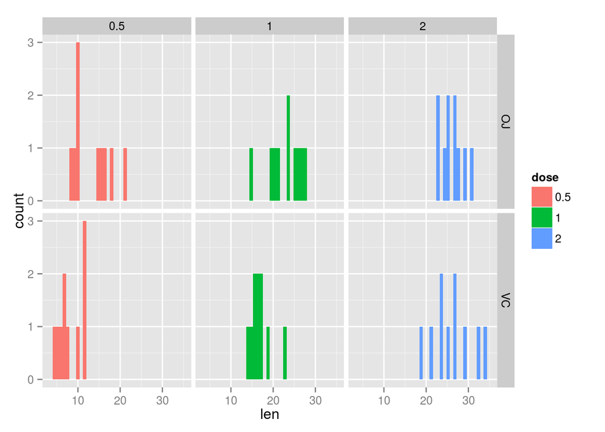

## 2. Provide a basic summary of the data.

- The data frame has 60 observation made by the same 10 guinea pigs.
- The data fram has 3 columns, which are len, supp and dose
- len represent the length of the teeth
- supp represent the supplement type
- dose represent dosage amount for the supplement

perhaps a statistic summary will help us understand the big picture

```
## Source: local data frame [6 x 4]
## Groups: supp [?]
##
##     supp   dose mean_len   var_len
##   (fctr) (fctr)    (dbl)     (dbl)
## 1     OJ    0.5    13.23 19.889000
## 2     OJ      1    22.70 15.295556
## 3     OJ      2    26.06  7.049333
## 4     VC    0.5     7.98  7.544000
## 5     VC      1    16.77  6.326778
## 6     VC      2    26.14 23.018222
```

## 3. Use confidence intervals and/or hypothesis tests to compare tooth growth by supp and dose. (Only use the techniques from class, even if there’s other approaches worth considering)

### 3.1. Confidence Interval

- I would like to find out if the increase in dosage has contributed to tooth growth using t-confidence test.
- **Assumption**: The growth in tooth is not affected by the age of the guinea pig.

```r
g1 <- RawData$len[1:10]
g2 <- RawData$len[11:20]
t.test(g2, g1, paired = TRUE)$conf
```

```
## [1]  5.549601 12.030399
## attr(,"conf.level")
## [1] 0.95
```

- As we can see the mean of difference will lie in the interval [5.55, 12.03], and thus confirming my early observation that higher dosage induce higer teeth growth.